# Math 425 Final Exam

Matt Hirschi

## Question 1 {c}

```r
model <- lm(volume ~ avgtemp + summer + avgtemp:summer, data = RailTrail)
summary(model)
```

```
##
## Call:
## lm(formula = volume ~ avgtemp + summer + avgtemp:summer, data = RailTrail)
##
## Residuals:
##      Min       1Q   Median       3Q      Max
## -297.587  -62.509   -4.394   57.382  272.091
##
## Coefficients:
##                Estimate Std. Error t value Pr(>|t|)
## (Intercept)    -162.201     95.166  -1.704 0.091917 .
## avgtemp           9.983      1.810   5.516 3.59e-07 ***
## summer          794.899    252.237   3.151 0.002237 **
## avgtemp:summer  -12.936      3.727  -3.471 0.000813 ***
## ---
## Signif. codes:  0 '***' 0.001 '**' 0.01 '*' 0.05 '.' 0.1 ' ' 1
##
## Residual standard error: 108.1 on 86 degrees of freedom
## Multiple R-squared:  0.3045, Adjusted R-squared:  0.2802
## F-statistic: 12.55 on 3 and 86 DF,  p-value: 7.003e-07
```

Open the RailTrail dataset from library(mosaic).

Perform an appropriate analysis in R to determine the slope of the “orangered” line in the plot below.

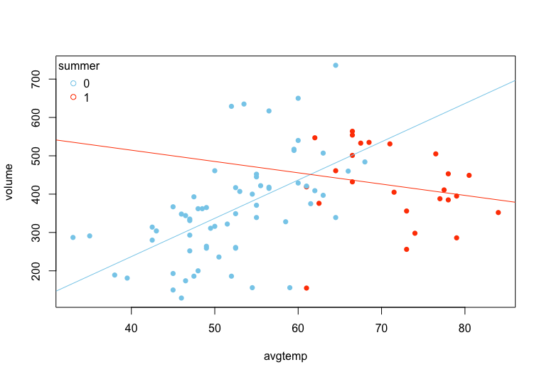

1. -2.581
2. -2.315
3. -2.953
4. -2.408

## Question 2 {c}

```r
model <- lm(weight ~ Time, data = ChickWeight)
summary(model)
```

```
##
## Call:
## lm(formula = weight ~ Time, data = ChickWeight)
##
## Residuals:
##      Min       1Q   Median       3Q      Max
## -138.331  -14.536    0.926   13.533  160.669
##
## Coefficients:
##             Estimate Std. Error t value Pr(>|t|)
## (Intercept)  27.4674     3.0365   9.046   <2e-16 ***
## Time          8.8030     0.2397  36.725   <2e-16 ***
## ---
## Signif. codes:  0 '***' 0.001 '**' 0.01 '*' 0.05 '.' 0.1 ' ' 1
##
## Residual standard error: 38.91 on 576 degrees of freedom
## Multiple R-squared:  0.7007, Adjusted R-squared:  0.7002
## F-statistic:  1349 on 1 and 576 DF,  p-value: < 2.2e-16
```

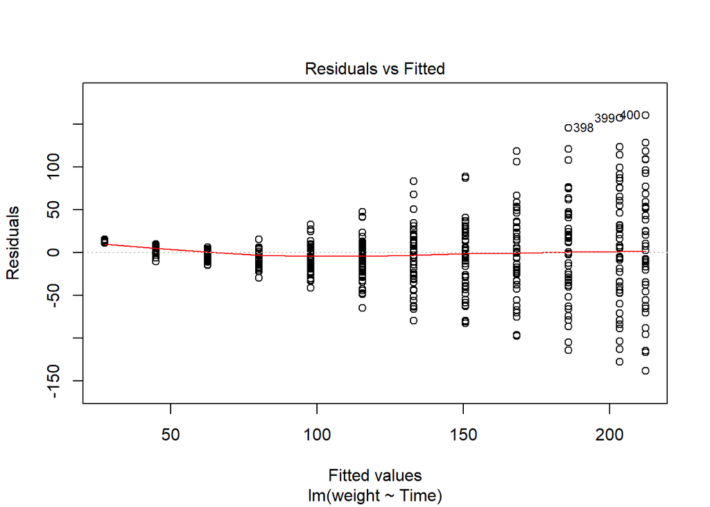

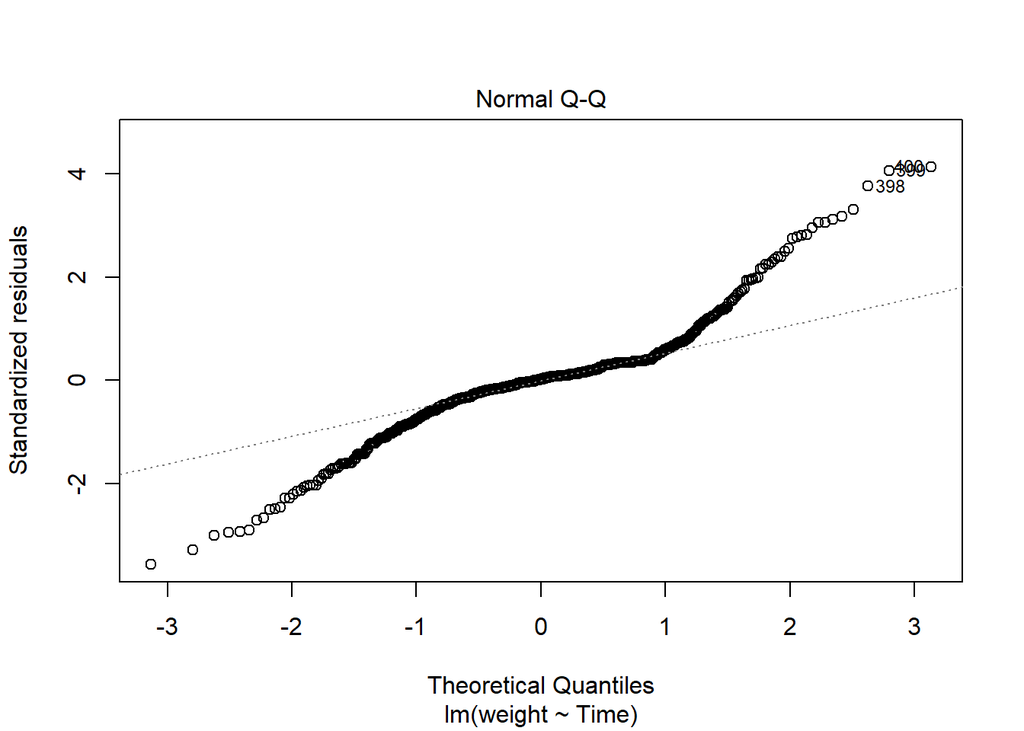

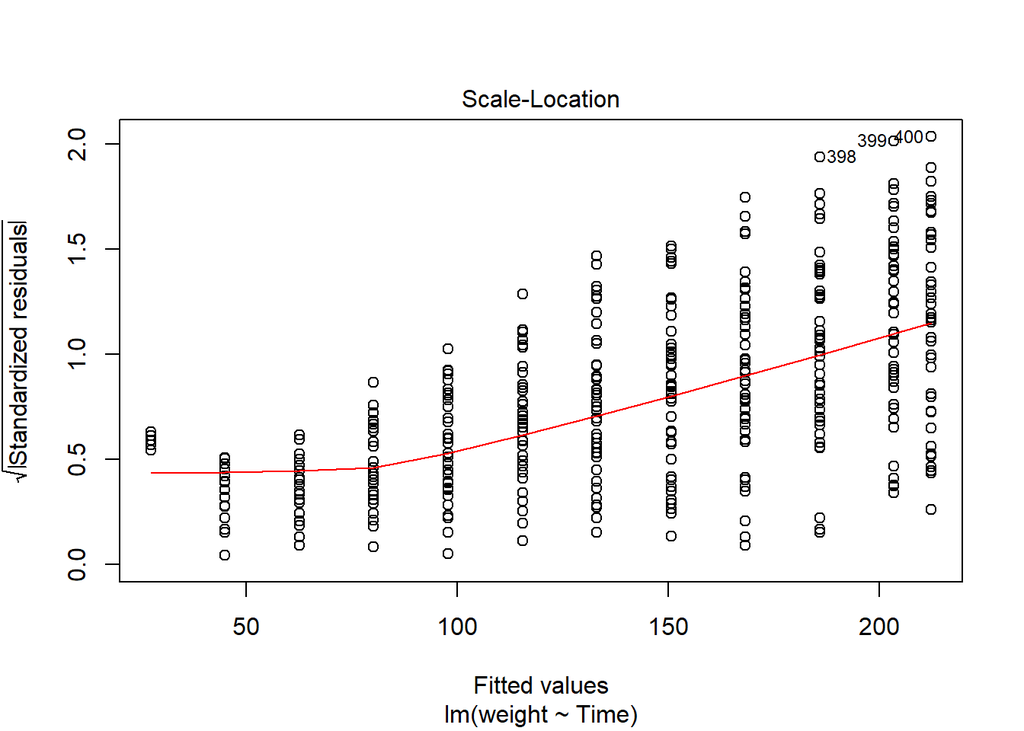

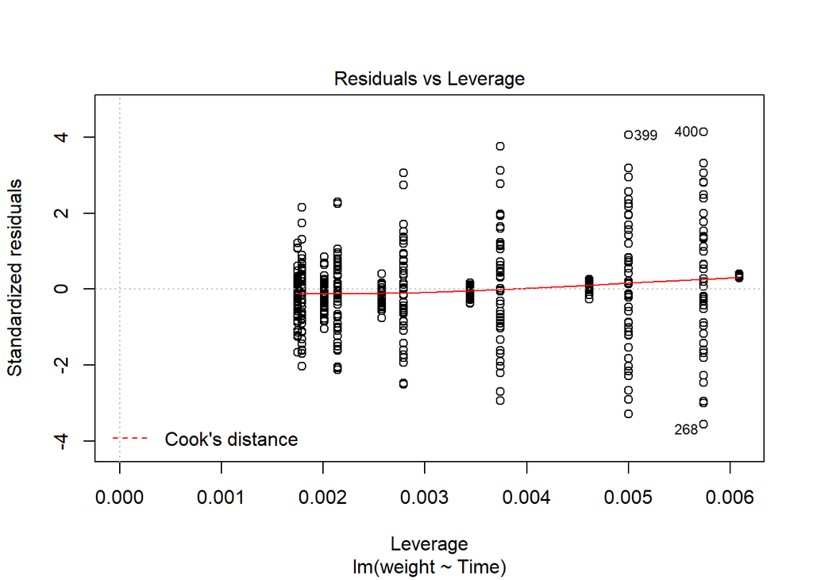

```r
plot(model)
```

Open the ChickWeight data set in R.

Perform a linear regression that predicts the weight of chickens according to how old the chick is in days.

Which of the following correctly diagnoses the appropriateness of this regression?

1. Everything looks good except for the non-normal errors.
2. The constant variance is violated, but linearity and normality look fine.
3. Constant Variance and normal errors are both violated, but the linear relation isn’t too bad.
4. Linear Relation is the only assumption being violated. The data looks to have constant variance and normal errors.

## Question 3 {a}

The points in all four scatter plots below are the same. Which of the following is the least squares regression line for these points?

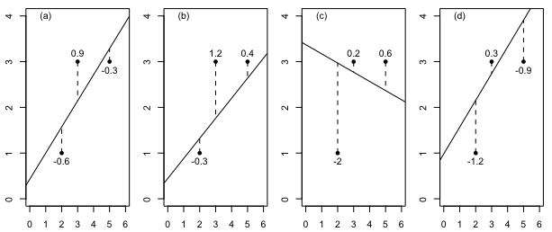

1. The plot on the left.
2. The plot in the middle-left.
3. The plot in the middle-right.
4. The plot on the right.

## Question 4 {c}

The points in all four plots below are the same. Which plot shows the robust regression line?

Here are the points if you are interested.

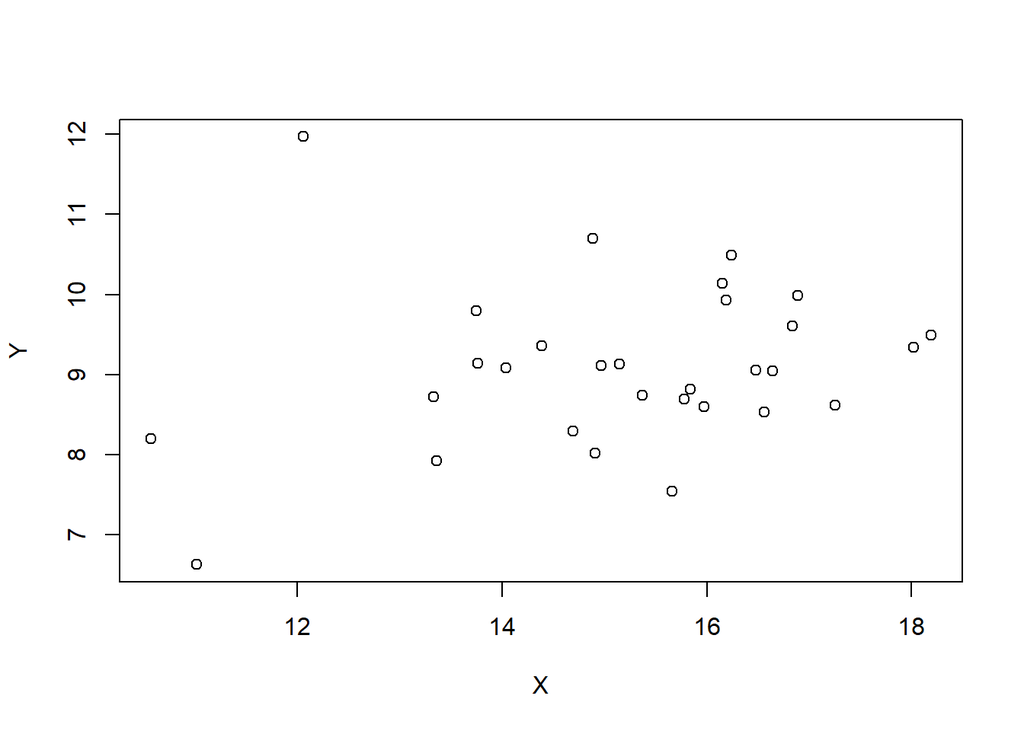

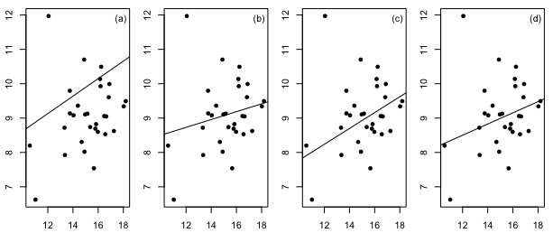

```r
Y <- c('9.8', '8.74', '8.72', '9.49', '7.54', '7.92', '8.6', '9.06', '10.14', '9.36', '9.34', '8.69', '9.14', '8.2', '8.62', '8.02', '9.11', '9.99', '9.05', '9.93', '9.61', '8.53', '9.13', '6.63', '10.49', '10.7', '8.3', '11.97', '9.08', '8.82')
X <- c('13.75', '15.37', '13.33', '18.19', '15.66', '13.36', '15.97', '16.48', '16.15', '14.39', '18.02', '15.78', '13.76', '10.57', '17.25', '14.91', '14.97', '16.89', '16.64', '16.19', '16.84', '16.56', '15.15', '11.02', '16.24', '14.89', '14.69', '12.06', '14.04', '15.84')

dat <- c(Y,X)

#model <- rlm(X ~ Y, data = dat)
plot(Y ~ X)
```

1. The plot on the left.
2. The plot in the middle-left.
3. The plot in the middle-right.
4. The plot on the right.

## Question 5 {c}

Fit an appropriate regression model to the following scatterplot using only the variables shown in the plot. Which of the following is the adjusted r-squared of a “best” model for this data?

```r
model <- lm(Temp ~ Month + I(Month^2), data = airquality)
summary(model)
```

```
##
## Call:
## lm(formula = Temp ~ Month + I(Month^2), data = airquality)
##
## Residuals:
##      Min       1Q   Median       3Q      Max
## -13.8311  -4.4446  -0.4446   3.5972  16.1689
##
## Coefficients:
##             Estimate Std. Error t value Pr(>|t|)
## (Intercept) -95.7256    15.2412  -6.281 3.46e-09 ***
## Month        48.7183     4.4889  10.853  < 2e-16 ***
## I(Month^2)   -3.2828     0.3199 -10.263  < 2e-16 ***
## ---
## Signif. codes:  0 '***' 0.001 '**' 0.01 '*' 0.05 '.' 0.1 ' ' 1
##
## Residual standard error: 6.624 on 150 degrees of freedom
## Multiple R-squared:  0.5166, Adjusted R-squared:  0.5102
## F-statistic: 80.16 on 2 and 150 DF,  p-value: < 2.2e-16
```

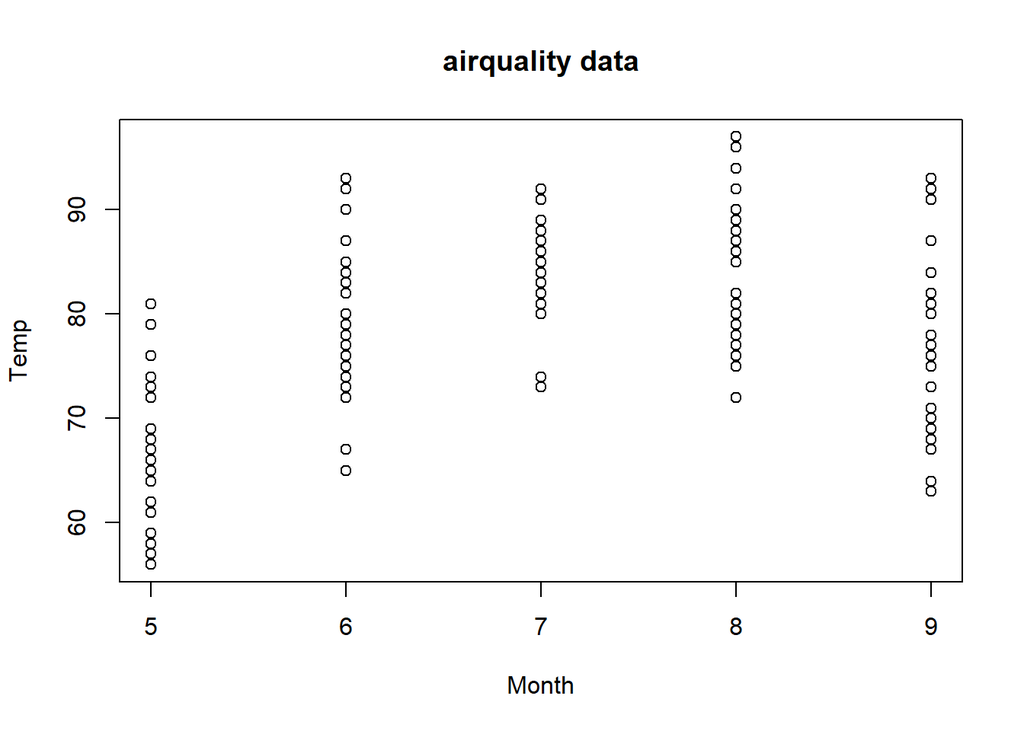

```r
plot(Temp ~ Month, data=airquality, main="airquality data")
```

1. 0.5895
2. 0.5075
3. 0.5102
4. 0.1717

## Question 6 {c}

Use the airquality dataset to fit the model

$$\underbrace{Y_i}_\text{Temp} = \beta_0 + \beta_1 \underbrace{X_{i1}}_\text{Wind} + \beta_2 \underbrace{X_{i2}}_\text{Month==7} + \beta_3 X_{i1}X_{i2} + \beta_4 \underbrace{X_{i3}}_\text{Month==9} + \beta_5 X_{i1} X_{i3} + \epsilon_i$$

```r
model <- lm(Temp ~ Wind + (Month==7) + Wind:(Month==7) + (Month==9) + Wind:(Month==9), data = subset(airquality, Month %in% c(5,7,9)))
summary(model)
```

```
##
## Call:
## lm(formula = Temp ~ Wind + (Month == 7) + Wind:(Month == 7) +
##     (Month == 9) + Wind:(Month == 9), data = subset(airquality,
##     Month %in% c(5, 7, 9)))
##
## Residuals:
##     Min      1Q  Median      3Q     Max
## -11.417  -4.130  -0.764   3.514  17.826
##
## Coefficients:
##                     Estimate Std. Error t value Pr(>|t|)
## (Intercept)          73.9697     3.7566  19.690  < 2e-16 ***
## Wind                 -0.7246     0.3097  -2.340  0.02162 *
## Month == 7TRUE       13.8133     5.0641   2.728  0.00773 **
## Month == 9TRUE       16.9497     5.1001   3.323  0.00131 **
## Wind:Month == 7TRUE   0.2907     0.4750   0.612  0.54221
## Wind:Month == 9TRUE  -0.6526     0.4463  -1.462  0.14732
## ---
## Signif. codes:  0 '***' 0.001 '**' 0.01 '*' 0.05 '.' 0.1 ' ' 1
##
## Residual standard error: 5.99 on 86 degrees of freedom
## Multiple R-squared:  0.6686, Adjusted R-squared:  0.6493
## F-statistic:  34.7 on 5 and 86 DF,  p-value: < 2.2e-16
```

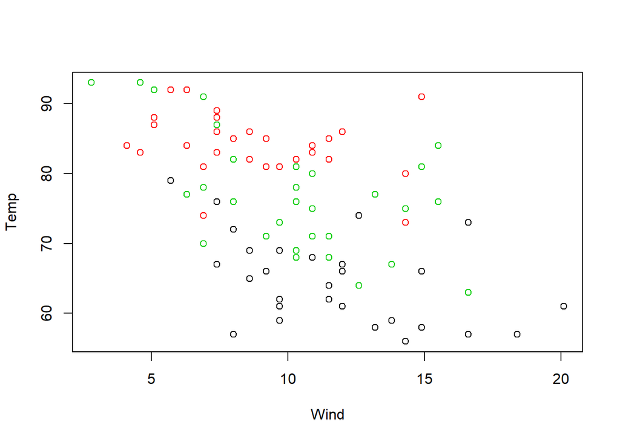

```r
plot(Temp ~ Wind, data=subset(airquality, Month %in% c(5,7,9)), col=as.factor(Month))
```

What is the estimate of $\beta_4$?

1. -0.6526
2. 0.2907
3. 16.9497
4. 13.8133

## Question 7 {a}

Consider the model $\overbrace{Y_i}^\text{dist} = \beta_0 + \beta_1 \overbrace{X_i}^\text{speed} + \epsilon_i$ for the cars data. Which of the following would add the most information to this model?

```r
X2 <- c(0, 0, 1, 0, 0, 1, 1, 0, 0, 1, 0, 1, 1, 1, 1, 1, 0, 0, 0, 1, 1, 0, 0, 1, 1, 0, 1, 1, 1, 1, 0, 1, 0, 0, 0, 1, 1, 0, 1, 1, 1, 1, 0, 1, 1, 1, 0, 0, 0, 0)
X3 <- c(13.7, 16.53, 17.4, 19.07, 15.29, 15.12, 14.3, 22.33, 11.04, 10.18, 11.29, 12.62, 14.45, 17.58, 9.02, 11.11, 11.19, 13.59, 18.51, 20.56, 13.98, 13.86, 14.96, 8.7, 18.79, 19.99, 12.81, 12.98, 18.02, 16.51, 11.13, 12.4, 9.94, 12.58, 9.98, 14.46, 15.08, 17.33, 12.64, 18.07, 21.49, 14.62, 16.79, 19.72, 20.33, 19.85, 18.84, 16.55, 13.71, 14.18)
X4 <- c(4.55, 4.53, 7.56, 7.51, 8.56, 9.54, 10.54, 10.3, 10.52, 11.39, 11.57, 12.6, 12.48, 12.44, 12.47, 13.54, 13.43, 13.7, 13.55, 14.35, 14.56, 14.7, 14.52, 15.58, 15.39, 15.44, 16.48, 16.45, 17.44, 17.73, 17.48, 18.52, 18.5, 18.46, 18.44, 19.61, 19.54, 19.56, 20.56, 20.58, 20.39, 20.41, 20.53, 22.4, 23.33, 24.34, 24.52, 24.56, 24.42, 25.59)
X5 <- c(16, 16, 49, 49, 64, 81, 100, 100, 100, 121, 121, 144, 144, 144, 144, 169, 169, 169, 169, 196, 196, 196, 196, 225, 225, 225, 256, 256, 289, 289, 289, 324, 324, 324, 324, 361, 361, 361, 400, 400, 400, 400, 400, 484, 529, 576, 576, 576, 576, 625)

dat <- c(cars,X2,X3,X4,X5)

model <- lm(dist ~ speed + X2, data = dat)
summary(model)
```

```
##
## Call:
## lm(formula = dist ~ speed + X2, data = dat)
##
## Residuals:
##      Min       1Q   Median       3Q      Max
## -19.1502  -7.2359   0.4245   4.6919  30.1136
##
## Coefficients:
##             Estimate Std. Error t value Pr(>|t|)
## (Intercept)   -7.855      4.479  -1.754    0.086 .
## speed          4.124      0.267  15.449  < 2e-16 ***
## X2           -23.483      2.804  -8.375 7.06e-11 ***
## ---
## Signif. codes:  0 '***' 0.001 '**' 0.01 '*' 0.05 '.' 0.1 ' ' 1
##
## Residual standard error: 9.845 on 47 degrees of freedom
## Multiple R-squared:   0.86,  Adjusted R-squared:  0.854
## F-statistic: 144.4 on 2 and 47 DF,  p-value: < 2.2e-16
```

```r
model2 <- lm(dist ~ speed + X5, data = dat)
summary(model2)
```

```
##
## Call:
## lm(formula = dist ~ speed + X5, data = dat)
##
## Residuals:
##     Min      1Q  Median      3Q     Max
## -28.720  -9.184  -3.188   4.628  45.152
##
## Coefficients:
##             Estimate Std. Error t value Pr(>|t|)
## (Intercept)  2.47014   14.81716   0.167    0.868
## speed        0.91329    2.03422   0.449    0.656
## X5           0.09996    0.06597   1.515    0.136
##
## Residual standard error: 15.18 on 47 degrees of freedom
## Multiple R-squared:  0.6673, Adjusted R-squared:  0.6532
## F-statistic: 47.14 on 2 and 47 DF,  p-value: 5.852e-12
```

1. `X2`
2. `X3`
3. `X4`
4. `X5`

```r
dat <- mtcars %>%
  filter(am == 1)
model <- lm(mpg ~ hp + I(hp^2) , data = dat)
predict(model, data.frame(hp = 150), interval = "prediction", level = 0.95)
```

```
##       fit      lwr      upr
## 1 20.2143 11.67206 28.75653
```

Use the `mtcars` dataset and a quadratic regression model to predict the average `mpg` for a manual transmission vehicle with `hp = 150` with 95% confidence.

1. (15.90904, 19.85342)
2. (16.41787, 19.34459)
3. (11.41947, 24.34299)
4. (9.172623, 26.58984)

What is the estimated value of $\sigma^2$ in the model

```r
model <- lm(Temp ~ Wind, data = airquality)
summary(model)
```

```
##
## Call:
## lm(formula = Temp ~ Wind, data = airquality)
##
## Residuals:
##     Min      1Q  Median      3Q     Max
## -23.291  -5.723   1.709   6.016  19.199
##
## Coefficients:
##             Estimate Std. Error t value Pr(>|t|)
## (Intercept)  90.1349     2.0522  43.921  < 2e-16 ***
## Wind         -1.2305     0.1944  -6.331 2.64e-09 ***
## ---
## Signif. codes:  0 '***' 0.001 '**' 0.01 '*' 0.05 '.' 0.1 ' ' 1
##
## Residual standard error: 8.442 on 151 degrees of freedom
## Multiple R-squared:  0.2098, Adjusted R-squared:  0.2045
## F-statistic: 40.08 on 1 and 151 DF,  p-value: 2.642e-09
```

$$Y_i = \beta_0 + \beta_1 X_i + \epsilon_i \quad \text{where} \ \epsilon_i \sim N(0, \sigma^2)$$

for $Y_i = \text{Temp}$ and $X_i = \text{Wind}$ in the `airquality` data set?

1. 8.442047
2. 71.26816
3. -1.2305
4. 90.1349

## Question 10 {c}

Use the `KidsFeet` data set (library(mosaic)) to obtain the value of the residual for the child named `Lang` in the simple linear regression that uses `length` of foot to predict `width` of foot?

```r
model <- lm(width ~ length, data = KidsFeet)

model$res
```

```
##           1           2           3           4           5           6
## -0.51220149 -0.36014925  0.76300373  0.68944030 -0.18576493  0.46546642
##           7           8           9          10          11          12
##  0.26628731  0.23492537  0.58615672  0.25972015  0.11916045 -0.11138060
##          13          14          15          16          17          18
## -0.23371269  0.24313433 -0.00891791 -0.83863806 -0.11302239 -0.18658582
##          19          20          21          22          23          24
## -0.48248134  0.31505597  0.38697761 -0.31220149 -0.51302239  0.06300373
##          25          26          27          28          29          30
## -0.76261194 -0.18166045  0.16628731  0.31505597  0.03738806  0.51177239
##          31          32          33          34          35          36
##  0.48697761  0.15889925 -0.33699627  0.28615672 -0.38658582 -0.04027985
##          37          38          39
## -0.30891791 -0.31794776 -0.16179104
```

1. -0.51302239
2. -0.48248134
3. -0.18576493
4. -0.23371269

## Question 11 {d}

Which of the following cominations could be values for SSE, SSR, and SSTO for the regression model $Y_i = \beta_0 + \beta_1 X_i + \epsilon_i$?

1. SSE = 178.05, SSR = 502.35, SSTO = 704.40
2. SSE = 6959.2, SSR = 102.48, SSTO = 8992.5
3. SSE = 57.149, SSR = 0.0024, SSTO = 57.147
4. SSE = 4.0557, SSR = 5.8120, SSTO = 9.8677

Which of the following statements contains no error?

1. $Y_i = \beta_0 + \beta_1 X_i + \epsilon_i \quad \text{where} \ \epsilon_i \sim N(0,\sigma^2_i)$
2. $Y_i = \beta_0 + \beta_1 X_{ii} + \beta_2 X_{ii} + \epsilon_i \quad \text{where} \ \epsilon_i \sim N(0, \sigma^2)$
3. $Y_i = \beta_i + \beta_0 X_{i1} + \beta_2 X_{i2} + \beta_3 \quad \text{where} \ \epsilon_i \sim N(0, \sigma^2)$
4. $Y_i = \beta_0 + \beta_1 X_{i1}' + \beta_2 X_{i2} + \epsilon_i \quad \text{where} \ \epsilon_i \sim N(0, \sigma^2)$

## Question 13 {a}

Which model from the list below has the best AIC criterian for the `KidsFeet` data set? Let $Y_i$ be `length`, $X_{1i}$ be `width`, $X_{2i}$ be 1 when girl and 0 when boy.

```r
model <- lm(length ~ width, data = KidsFeet)
model2 <- lm(length ~ sex, data = KidsFeet)
model3 <- lm(length ~ width + sex, data = KidsFeet)
model4 <- lm(length ~ width + sex + width:sex, data = KidsFeet)
```

1. $Y_i = \beta_0 + \beta_1 X_{1i} + \epsilon_i$
2. $Y_i = \beta_0 + \beta_1 X_{2i} + \epsilon_i$
3. $Y_i = \beta_0 + \beta_1 X_{1i} + \beta_2 X_{2i} + \epsilon_i$
4. $Y_i = \beta_0 + \beta_1 X_{1i} + \beta_2 X_{2i} + \beta_3 X_{1i} X_{2i} + \epsilon_i$

## Question 14 {c}

Open the `mtcars` data set. A simple linear regression of vehicle `mpg` on `qsec` is performed. Which Y transformation produces the highest $R^2$ value?

```r
model <- lm((1/mpg) ~ qsec, data = mtcars)
summary(model)
```

```
##
## Call:
## lm(formula = (1/mpg) ~ qsec, data = mtcars)
##
## Residuals:
##       Min        1Q    Median        3Q       Max
## -0.024697 -0.010044 -0.001199  0.007805  0.042392
##
## Coefficients:
##              Estimate Std. Error t value Pr(>|t|)
## (Intercept)  0.117527   0.027766   4.233 0.000201 ***
## qsec        -0.003546   0.001548  -2.291 0.029176 *
## ---
## Signif. codes:  0 '***' 0.001 '**' 0.01 '*' 0.05 '.' 0.1 ' ' 1
##
## Residual standard error: 0.0154 on 30 degrees of freedom
## Multiple R-squared:  0.1489, Adjusted R-squared:  0.1205
## F-statistic: 5.248 on 1 and 30 DF,  p-value: 0.02918
```

1. $Y' = \log(Y)$
2. $Y' = Y$
3. $Y' = \sqrt{Y}$
4. $Y' = 1/Y$

## Question 15 {b}

Would a residual of 3.8 be considered an outlier or a typical value in the regression of `mpg` on `drat`?

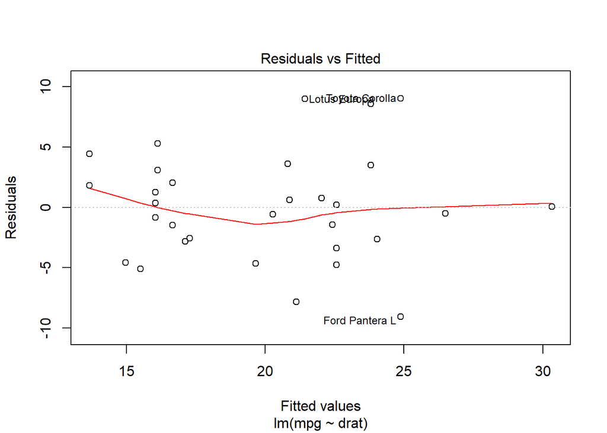

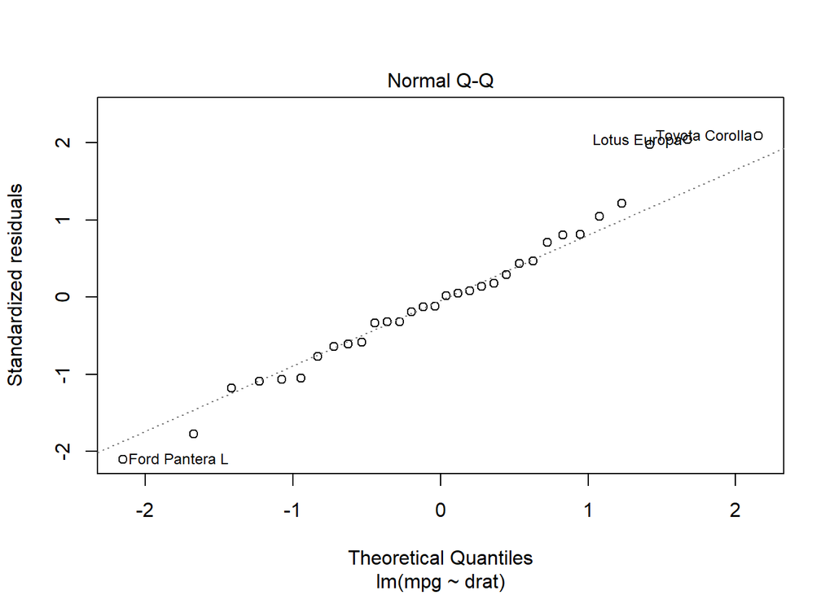

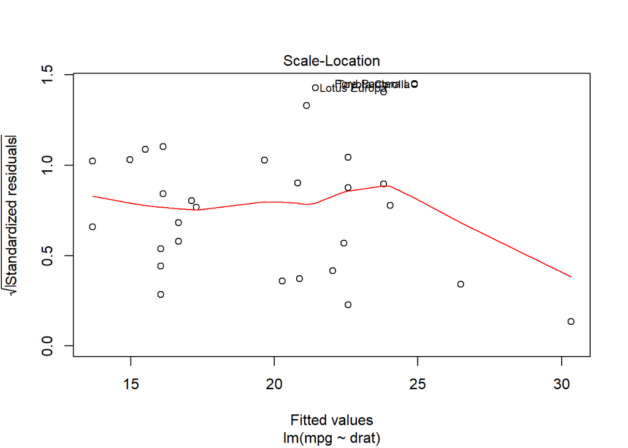

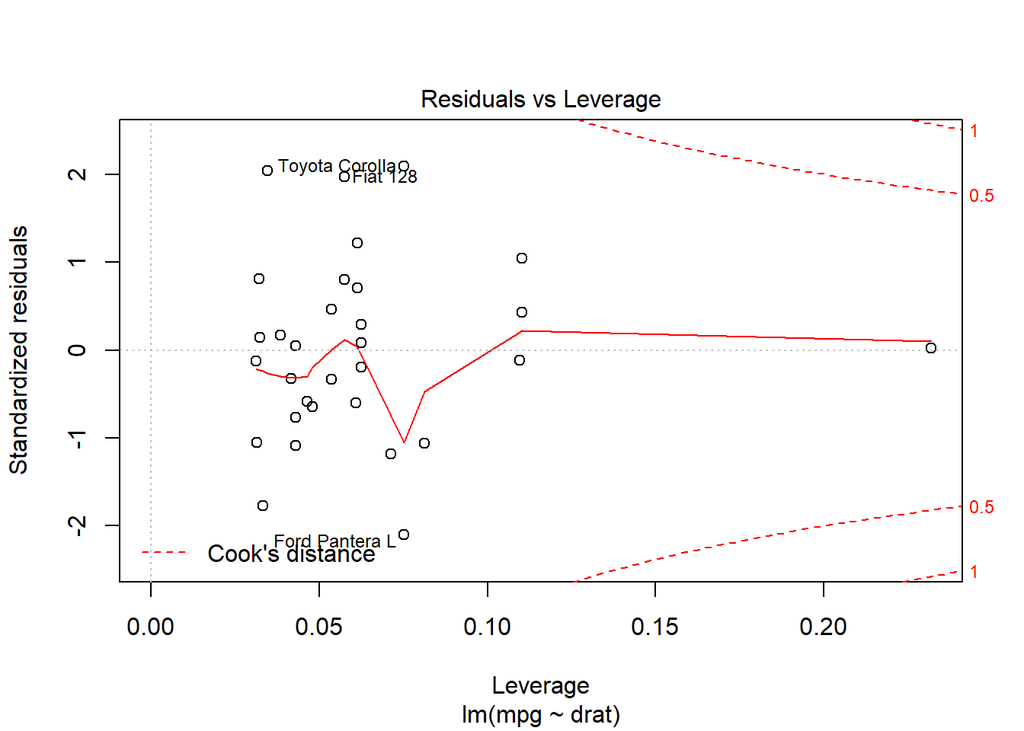

```r
model <- lm(mpg ~ drat, data = mtcars)
plot(model)
```

(a) A residual of 3.8 would be surprisingly small for this regression.

2. A residual of 3.8 would be quite typical for this regression.
3. A residual of 3.8 would be exceptionally large for this regression.
4. A residual of 3.8 would be somewhat extreme, but not impossible for this regression.

## Question 16 {b}

A regression of the square root of circumference is performed on the explanatory variable of age using the `Orange` data set. Which of the following plots correctly shows this regression in the original units?

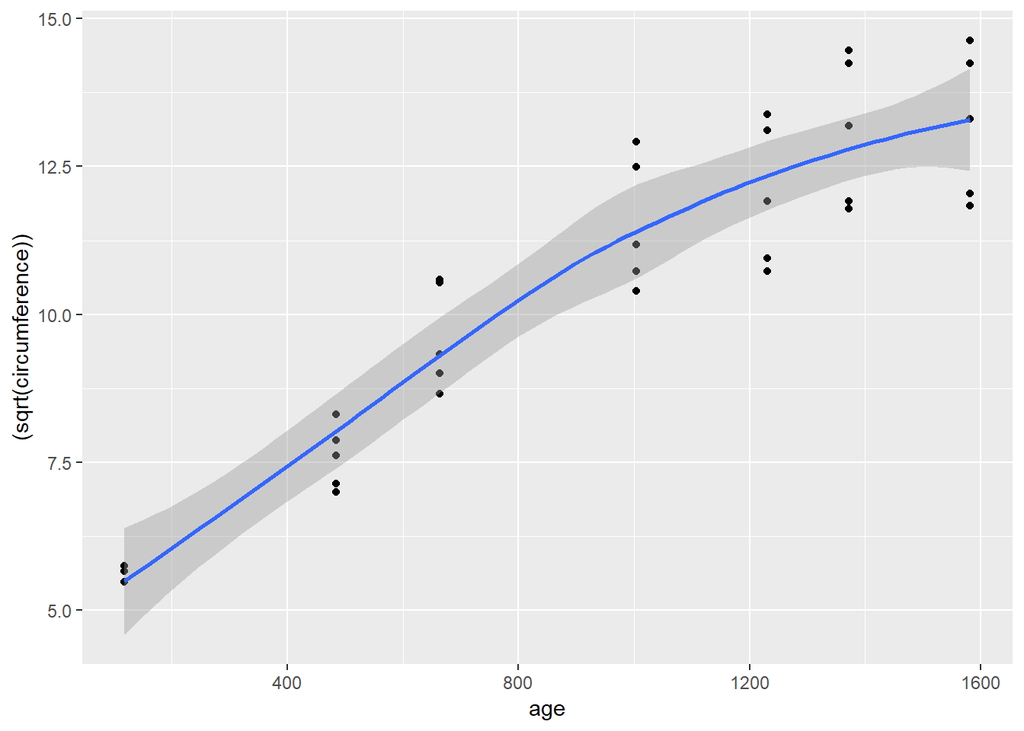

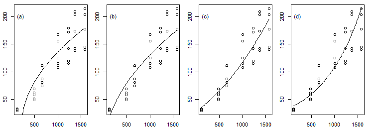

```r
Orange %>%
  ggplot(aes(x = age, y = (sqrt(circumference))))+
           geom_point()+
           geom_smooth()
```

1. The plot on the left.
2. The plot in the middle-left.
3. The plot in the middle-right.
4. The plot on the right.

## Question 17 {a}

Use the regression output below to predict the average length of feet for girls with a foot width of 8.2 cm.

```r
model <- lm(length ~ width + sex, data=KidsFeet)


predict(model, data.frame(width = 8.2, sex = "G"), response = "prediction")
```

```
##        1
## 23.38376
```

1. 23.38376 cm
2. 41.55233 cm
3. 18.22010 cm
4. 21.95480 cm

## Question 18 {c}

Which of the following regressions least satisfies the constant variance requirement for the airquality data set?

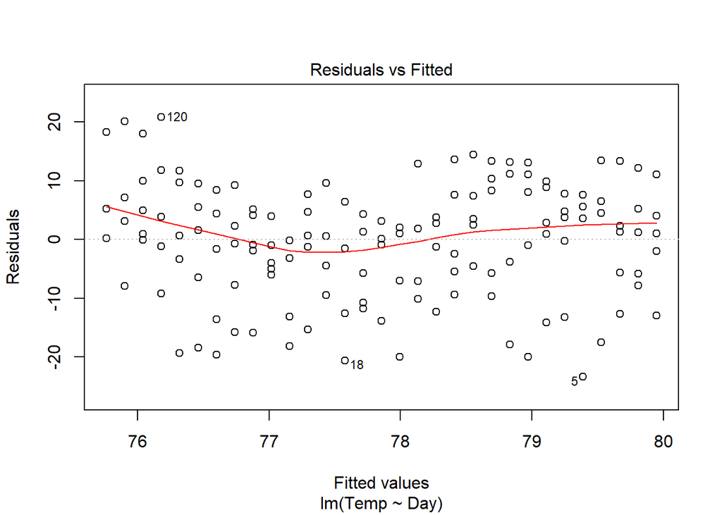

```r
model <- lm(Temp ~ Day, data = airquality)
model2 <- lm(Wind ~ Temp, data = airquality)
model3 <- lm(Month ~ Day, data = airquality)
model4 <- lm(Solar.R ~ Temp, data = airquality)

plot(model, which = 1)
```

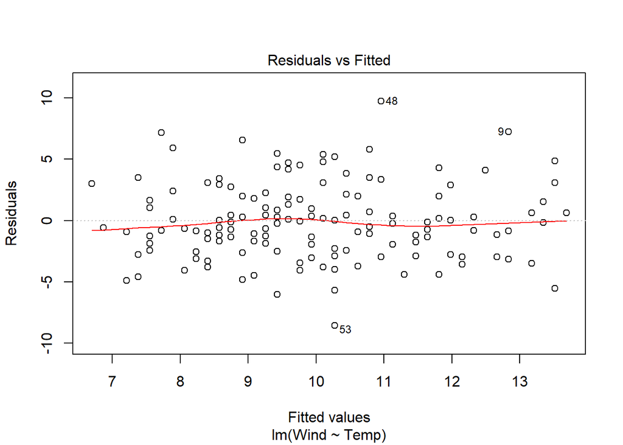

```r
plot(model2, which = 1)
```

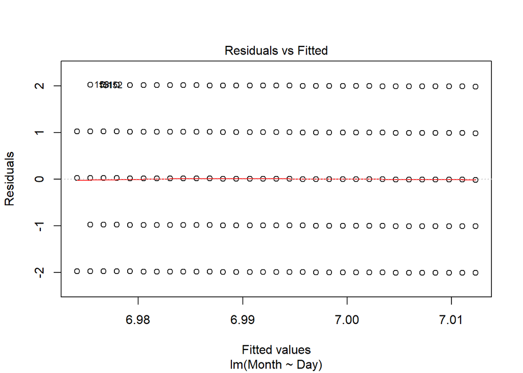

```r
plot(model3, which = 1)
```

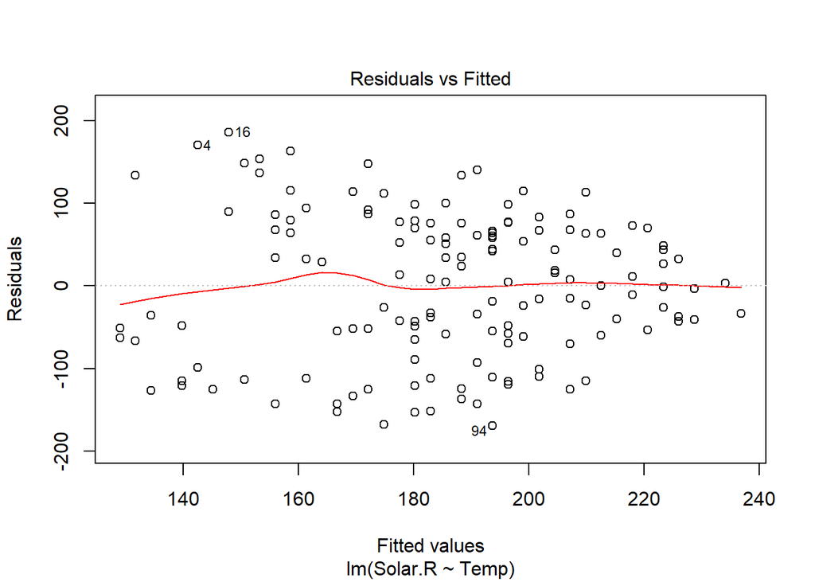

```r
plot(model4, which = 1)
```

1. lm(Temp ~ Day)
2. lm(Wind ~ Temp)
3. lm(Month ~ Day)
4. lm(Solar.R ~ Temp)

Perform a lack-of-fit test for the `mtcars` data with `mpg` on the explanatoary variable of `cyl`.

Report the p-value and conclusion of the test.

```r
model <- lm(mpg ~ cyl, data = mtcars)
pureErrorAnova(model)
```

```
## Analysis of Variance Table
##
## Response: mpg
##              Df Sum Sq Mean Sq F value    Pr(>F)
## cyl           1 817.71  817.71 78.7143 9.266e-10 ***
## Residuals    30 308.33   10.28
##  Lack of fit  1   7.07    7.07  0.6807    0.4161
##  Pure Error  29 301.26   10.39
## ---
## Signif. codes:  0 '***' 0.001 '**' 0.01 '*' 0.05 '.' 0.1 ' ' 1
```

1. p-value = 0.4161, which shows evidence of a non-linear pattern.
2. p-value = 9.266e-10, which shows evidence of a non-linear pattern.
3. p-value = 0.4161, which shows we can assume linearity of the data.
4. p-value = 9.266e-10, which shows we can assume linearity of the data.

Test the hypothesis $H_0: \beta_1 = -3$ against $H_a: \beta_1 > -3$ in the regression of `mpg ~ cyl` from the `mtcars` data set. Select the p-value of the test.

```r
model <- lm(mpg ~ cyl, data = mtcars)
summary(model)
```

```
##
## Call:
## lm(formula = mpg ~ cyl, data = mtcars)
##
## Residuals:
##     Min      1Q  Median      3Q     Max
## -4.9814 -2.1185  0.2217  1.0717  7.5186
##
## Coefficients:
##             Estimate Std. Error t value Pr(>|t|)
## (Intercept)  37.8846     2.0738   18.27  < 2e-16 ***
## cyl          -2.8758     0.3224   -8.92 6.11e-10 ***
## ---
## Signif. codes:  0 '***' 0.001 '**' 0.01 '*' 0.05 '.' 0.1 ' ' 1
##
## Residual standard error: 3.206 on 30 degrees of freedom
## Multiple R-squared:  0.7262, Adjusted R-squared:  0.7171
## F-statistic: 79.56 on 1 and 30 DF,  p-value: 6.113e-10
```

1. 0.3852357
2. 0.3513904
3. 6.11e-10
4. 5.98e-09

## Question 21 {d}

Interpret the slope in context of the model

$$\underbrace{Y_i}_\text{mpg} = \beta_0 + \beta_1 \underbrace{X_i}_\text{cyl} + \epsilon_i$$

1. There is a -2.8758 chage in `mpg` for every 1 unit increase in `cyl`.
2. There is a -2.8758 change in `mpg`, on average, for every 1 unit increase in `cyl`.
3. There is an average change of -2.8758 in `mpg` for every 1 unit increase in `cyl`.
4. There is a -2.8758 change in the average `mpg` for every 1 unit incrase in `cyl`.

Compute the value of $SSE$ for the model

$$\underbrace{Y_i}_\text{mpg} = \beta_0 + \beta_1 \underbrace{X_i}_\text{cyl} + \epsilon_i \quad \text{where} \ \epsilon_i \sim N(0, \sigma^2)$$

1. 818
2. 308
3. 80
4. 10

## Question 23 {d}

Which scatterplot is best suited for a double quadratic model?

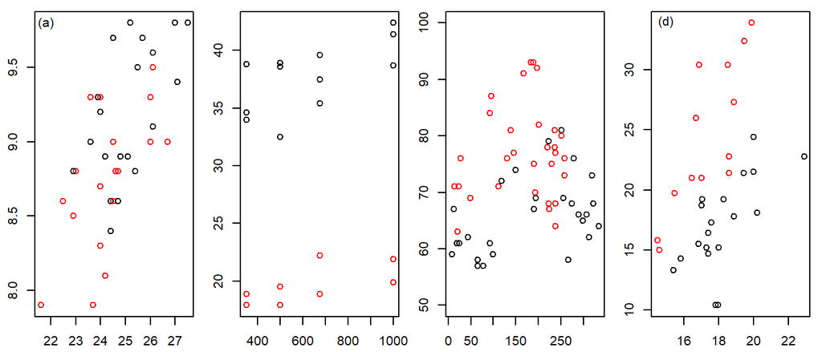

```r
par(mfrow=c(1,4), mai=c(.3,.3,.1,.1))
plot(width ~ length, data=KidsFeet, col=as.factor(sex))
text(21.8,9.8,"(a)")
plot(uptake ~ conc, data=subset(CO2, conc>250 & Treatment=="chilled" & Plant != "Mc2"), col=Type)
text(205,42.5,"(b)")
plot(Temp ~ Solar.R, data=subset(airquality, Month %in% c(5,9)), col=as.factor(Month), ylim=c(50,100))
text(58,333,"(c)")
plot(mpg ~ qsec, data=mtcars, col=as.factor(am))
text(15, 34, "(d)")
```

1. The left plot.
2. The middle-left plot.
3. The middle-right plot.
4. The right plot.

Which graph shows a scenario where SSE is larger than the SSR?

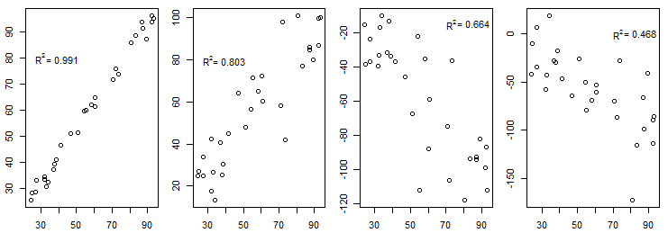

1. The plot on the left.
2. The plot in the middle-left.
3. The plot in the middle-right.
4. The plot on the right.

## Question 25 {a}

What type of analysis would be most appropriate for predicting whether or not a student will have a job upon graduation based on their GPA?

1. A logistic regression model.
2. A two-lines regression model.
3. A double quadratic regression model.
4. A three-dimensional regression model.